# Initial analyses

Jacob J. Bukoski

November 28, 2018

### Structure of datasets:

- Krabi
  - 7 transects
    - 5 plots per transect, all with aboveground characteristics
    - 4 plots per transect with soil and aboveground characteristics
- Nakorn
  - 10 transects
    - 5 plots per transect, all with aboveground characteristics
    - 2 plots per transect with soil and aboveground characteristics
      - Will collect additional 2 plots

### Locations of the data

Basic visualization of where the data sits. Data are summarized at the plot level, and attached to the markers on the map.

- Can view plot-level data by clicking.
- Can also adjust basemap layer.

[interactive chart not shown]

## Initial passes and visualizations of the data

#### Total biomass ~ Basal area @ plot level

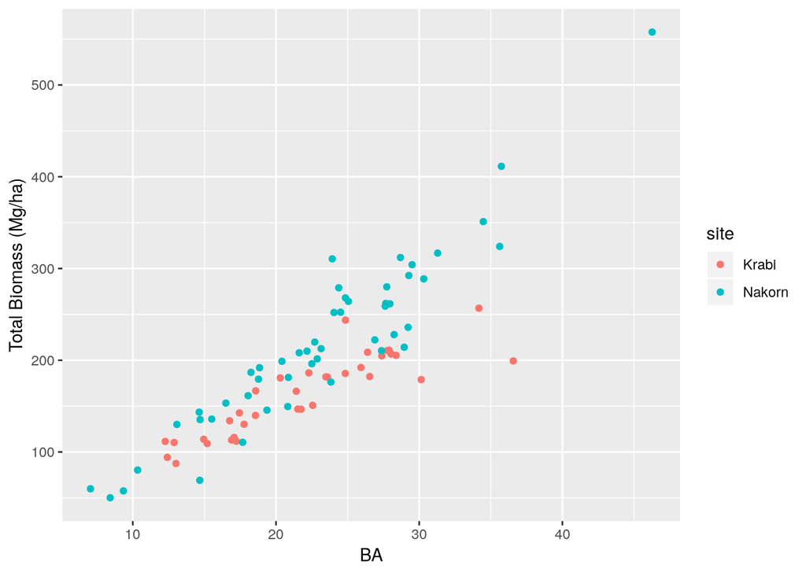

#### Total biomass ~ plot

Relatively minor differences in biomass across sites, though slightly higher in Nakorn.

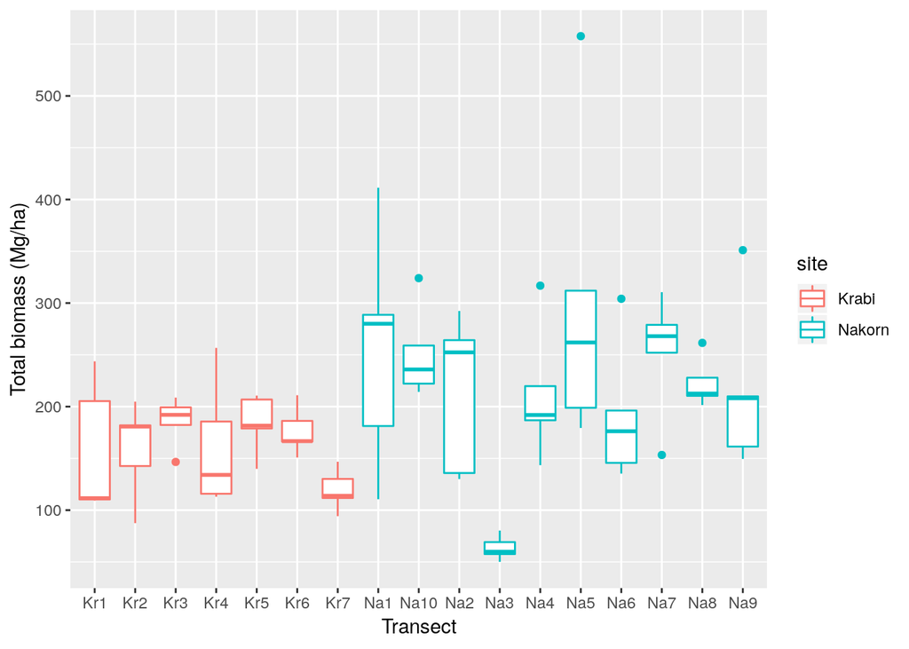

## Soil parameters across both sites

Can begin to see the differences in soil parameters at site level here. Plotted as scatter plots as Nakorn only has two plots per site.

#### Bulk density ~ transect

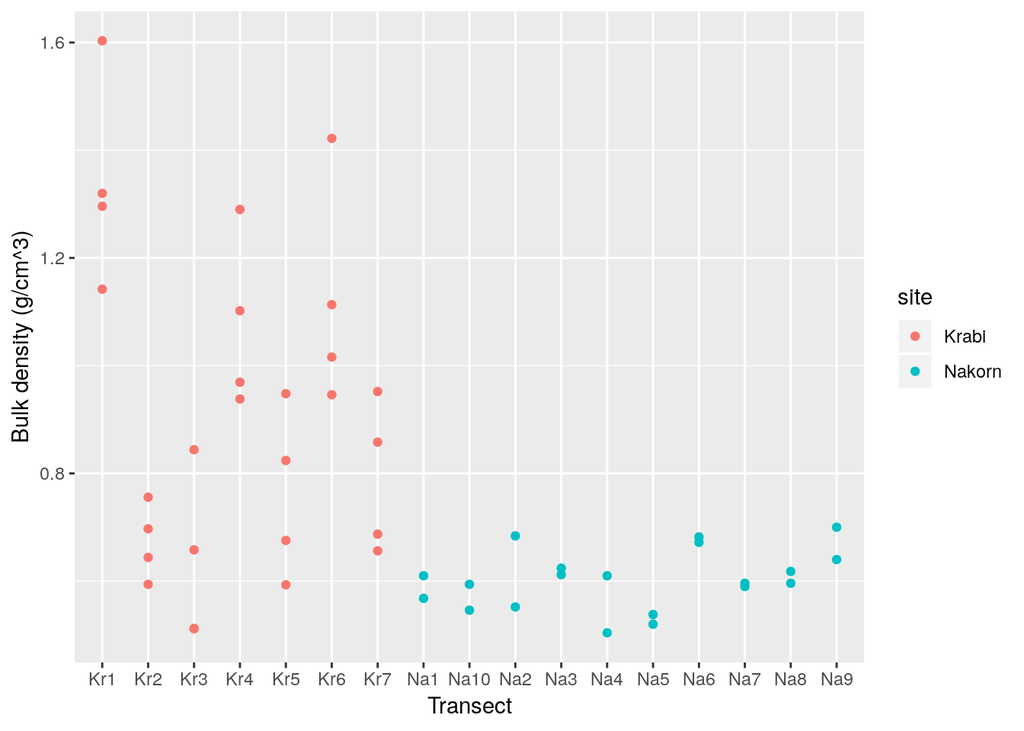

#### Percent organic carbon ~ transect

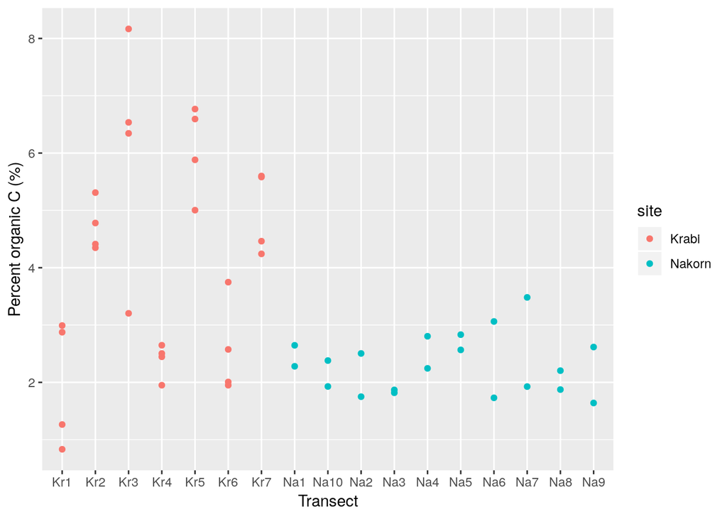

#### Soil carbon density (mg/cm^3) ~ transect

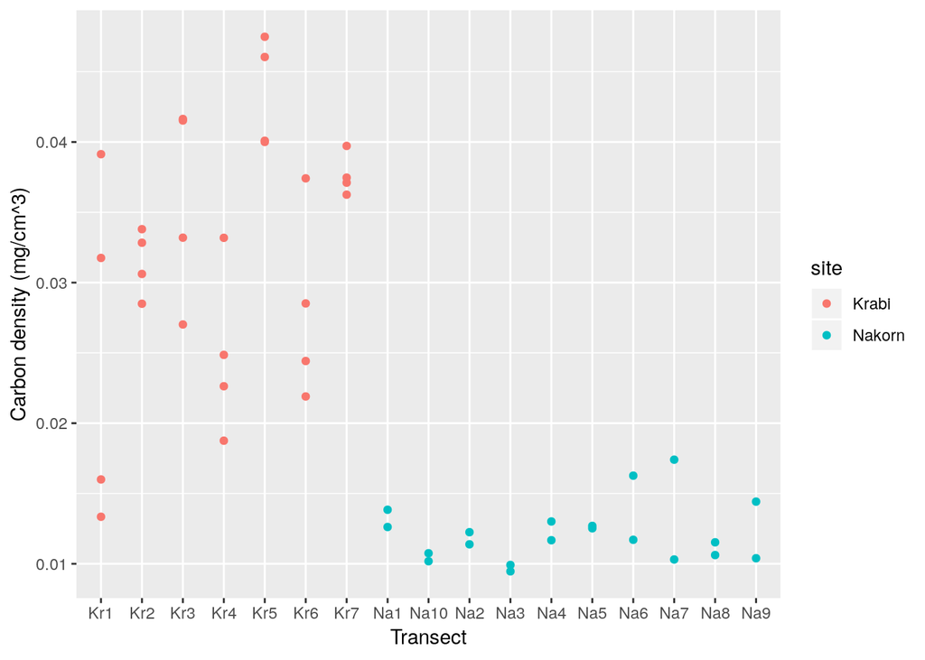

#### Soil organic carbon to mean depth (Mg/ha) ~ transect

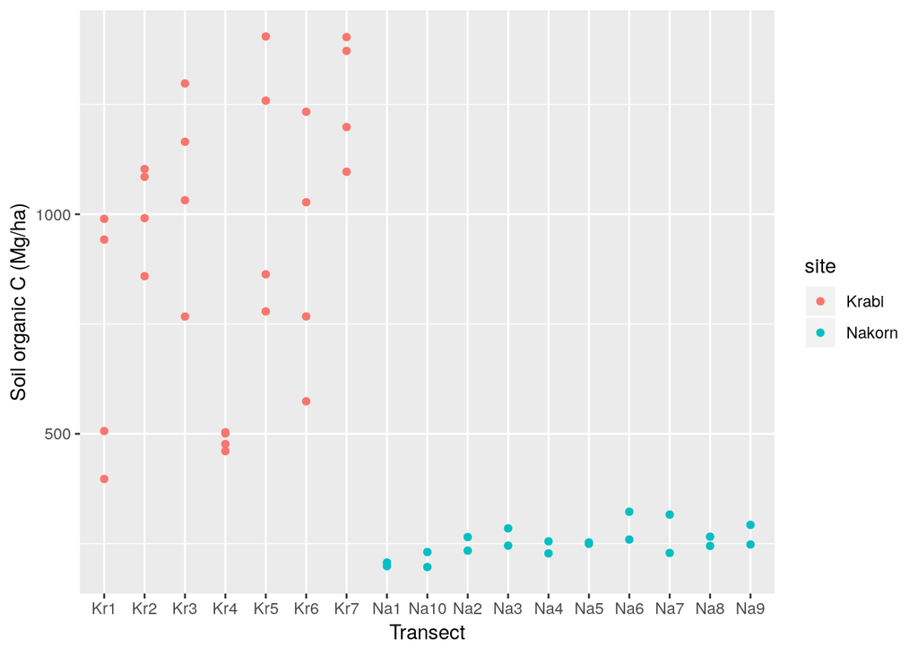

# Looking at things by dominant genus/species

Summary of counts of plots of different dominant genus (plots from both sites pooled). Rh, Br, etc., are genus abbreviations. “Rh” alone is a plot with 80% dominance of that genus, “Rh_mix” is plot dominated by that genus but < 80%.

```
## # A tibble: 6 x 2
## # Groups:   dom_genus [6]
##   dom_genus     n
##   <chr>     <int>
## 1 rh            7
## 2 br_mix        7
## 3 rh_mix       22
## 4 av_mix        5
## 5 xy_mix        4
## 6 br            3
```

Structure of the dominant genus-labeled plots at the site level - pretty unbalanced. Rhizophora dominated plots (rh_mix) are by far most prevalent in Krabi.

```
## # A tibble: 10 x 3
## # Groups:   site, dom_genus [10]
##    site   dom_genus     n
##    <chr>  <chr>     <int>
##  1 Krabi  rh            5
##  2 Krabi  br_mix        1
##  3 Krabi  rh_mix       17
##  4 Krabi  av_mix        1
##  5 Krabi  xy_mix        4
##  6 Nakorn br_mix        6
##  7 Nakorn br            3
##  8 Nakorn av_mix        4
##  9 Nakorn rh_mix        5
## 10 Nakorn rh            2
```

#### Total biomass ~ dominant genus

*Note*: Dominant genus is equally weighted importance index of frequency, dominance, and density at genus level. Dominant species is calculated in same fashion but at species level.

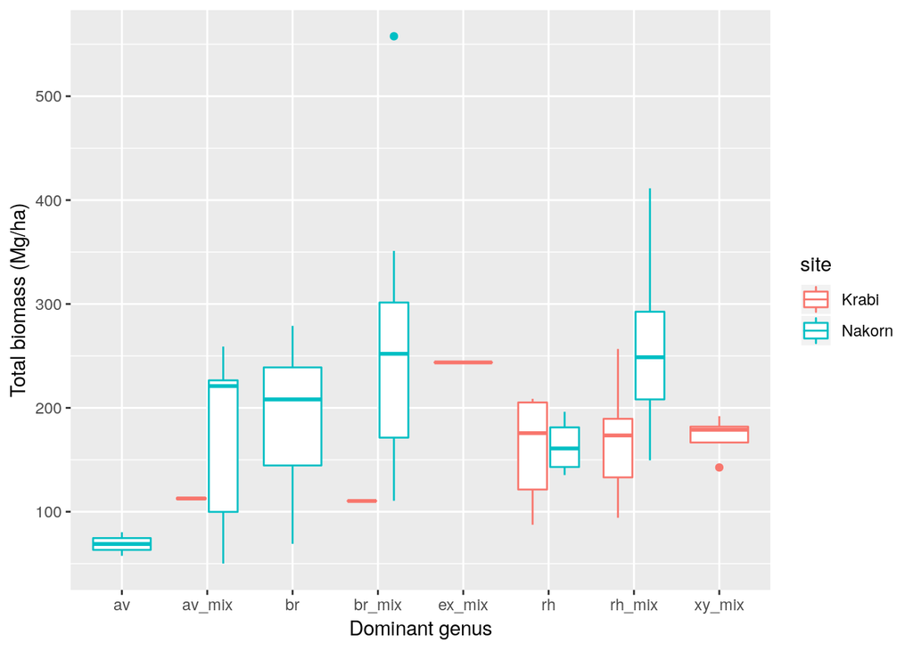

#### Bulk density ~ dominant genus

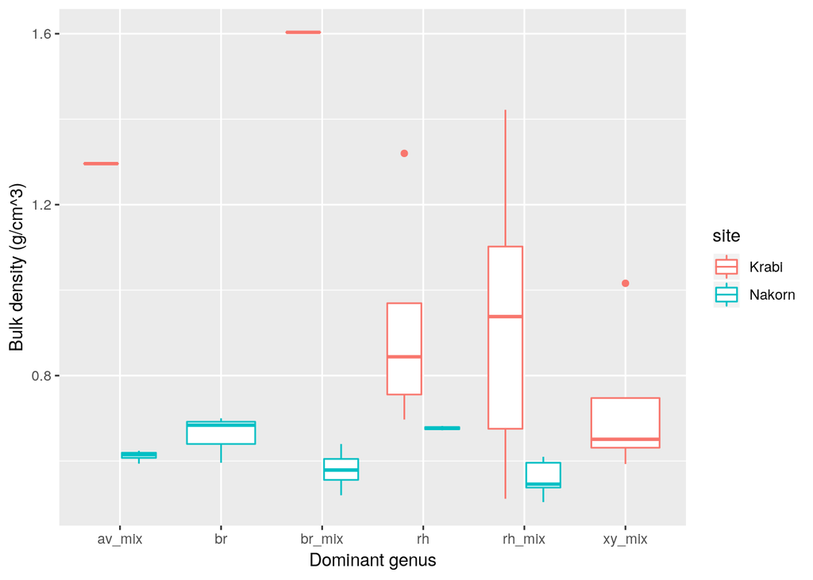

#### Percent organic carbon (%) ~ dominant genus

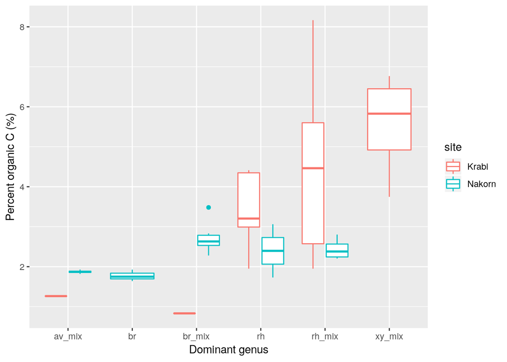

#### Soil carbon density (mg/cm^3) ~ dominant genus

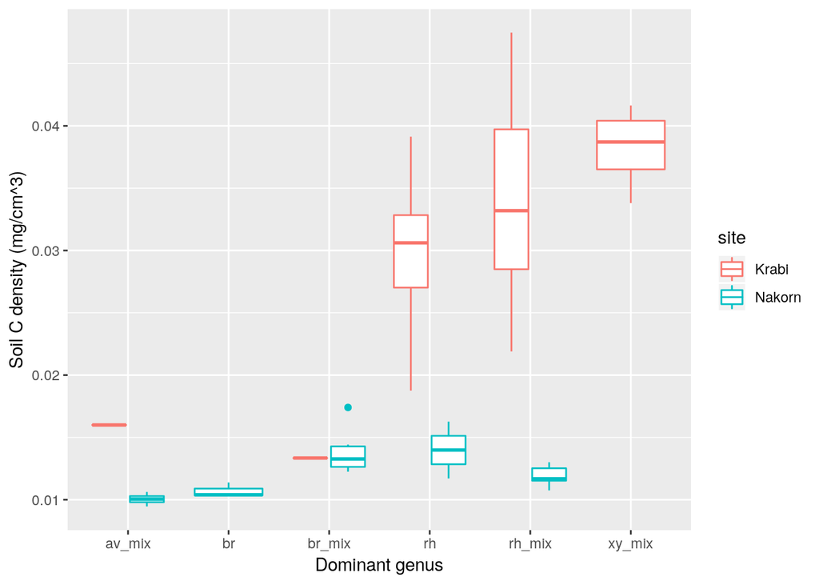

#### Soil carbon density (Mg/ha to mean soil depth) ~ dominant genus

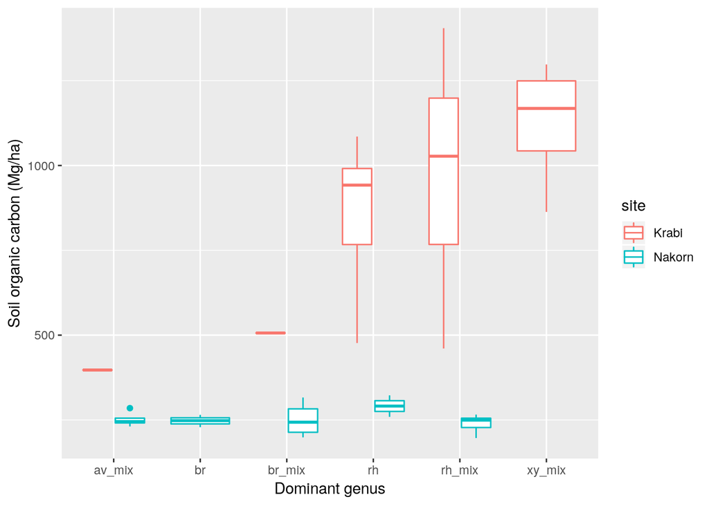

# Autocorrelation

## Autocorrelation at within site level for Krabi

#### Total biomass, Krabi

```
##
##  Monte-Carlo simulation of Moran I
##
## data:  krabi_sp$sbplt_t_
## weights: nbw
## number of simulations + 1: 100
##
## statistic = 0.025335, observed rank = 80, p-value = 0.2
## alternative hypothesis: greater
```

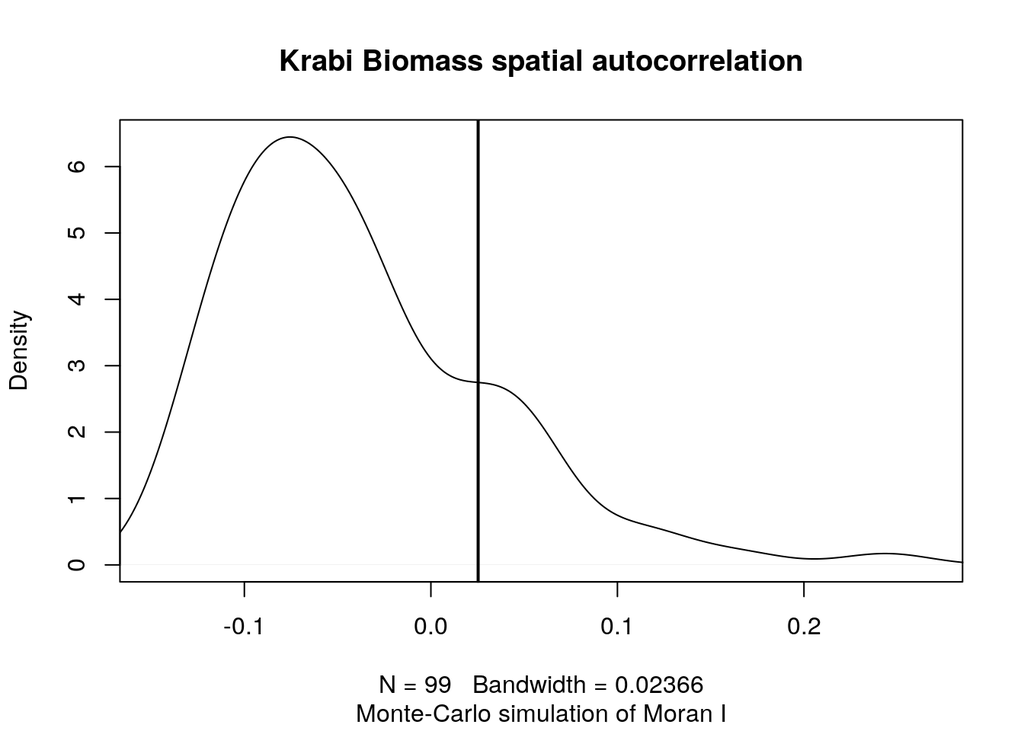

#### Soil bulk density, Krabi

```
##
##  Monte-Carlo simulation of Moran I
##
## data:  krabi_sp$sbplt_bd
## weights: nbw
## number of simulations + 1: 100
##
## statistic = 0.085229, observed rank = 94, p-value = 0.06
## alternative hypothesis: greater
```

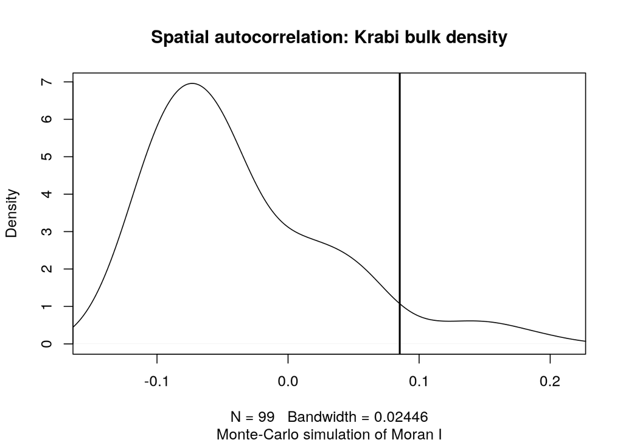

#### Soil percent organic carbon, Krabi

```
##
##  Monte-Carlo simulation of Moran I
##
## data:  krabi_sp$sbplt_p
## weights: nbw
## number of simulations + 1: 100
##
## statistic = 0.081113, observed rank = 88, p-value = 0.12
## alternative hypothesis: greater
```

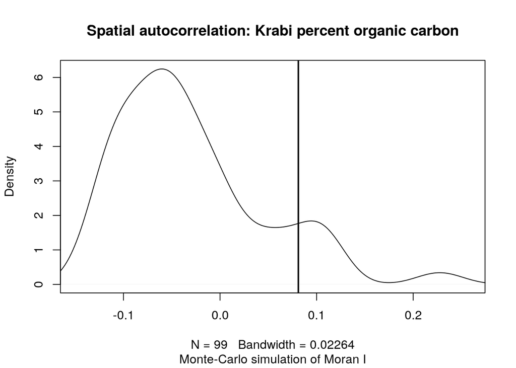

#### Soil carbon density, Krabi

```
##
##  Monte-Carlo simulation of Moran I
##
## data:  krabi_sp$sbplt_c_
## weights: nbw
## number of simulations + 1: 100
##
## statistic = 0.082543, observed rank = 94, p-value = 0.06
## alternative hypothesis: greater
```

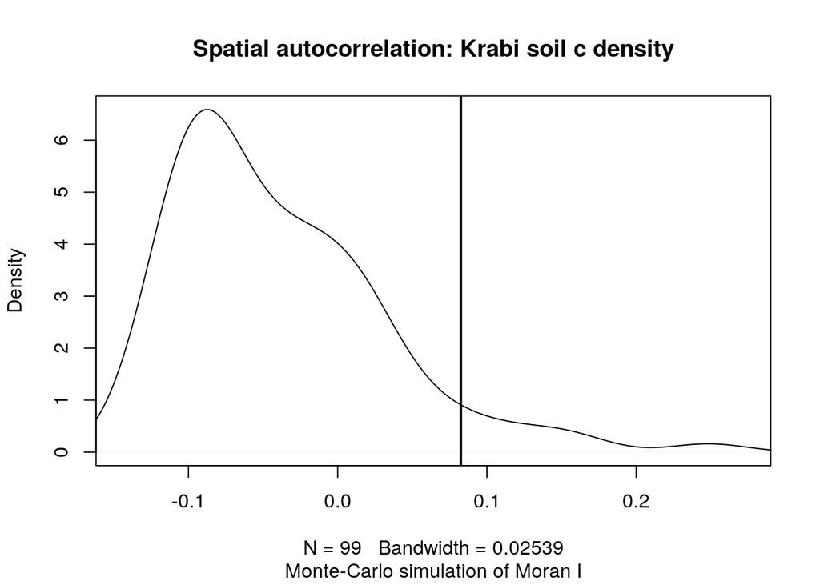

## Autocorrelation at within-site level for Nakorn

#### Total biomass, Nakorn

```
##
##  Monte-Carlo simulation of Moran I
##
## data:  nakorn_sp$sbplt_t_
## weights: nbw
## number of simulations + 1: 100
##
## statistic = -0.0018012, observed rank = 69, p-value = 0.31
## alternative hypothesis: greater
```

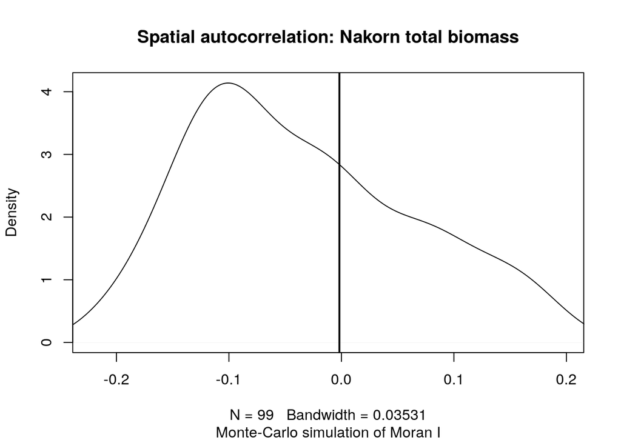

#### Soil bulk density, Nakorn

```
##
##  Monte-Carlo simulation of Moran I
##
## data:  nakorn_sp$sbplt_bd
## weights: nbw
## number of simulations + 1: 100
##
## statistic = -0.085542, observed rank = 30, p-value = 0.7
## alternative hypothesis: greater
```

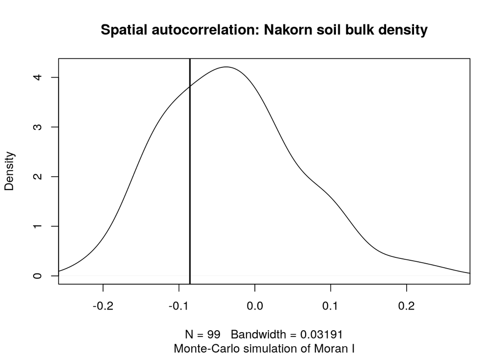

#### Soil percent organic carbon, Nakorn

```
##
##  Monte-Carlo simulation of Moran I
##
## data:  nakorn_sp$sbplt_p
## weights: nbw
## number of simulations + 1: 100
##
## statistic = 0.014577, observed rank = 85, p-value = 0.15
## alternative hypothesis: greater
```

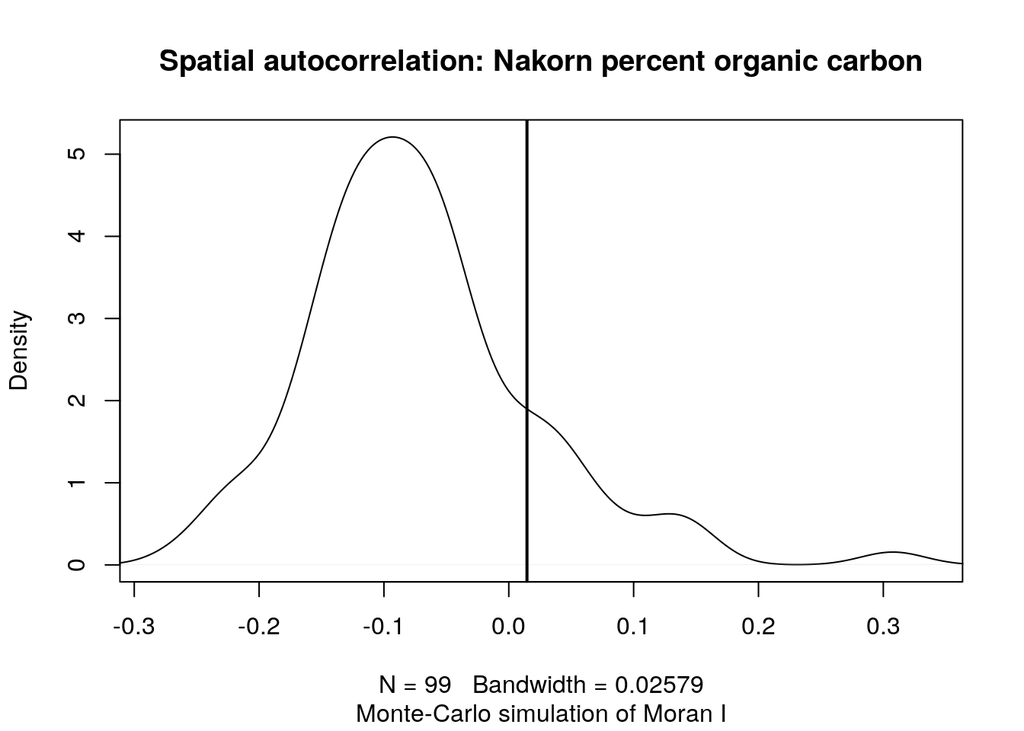

#### Soil carbon density, Nakorn

```
##
##  Monte-Carlo simulation of Moran I
##
## data:  nakorn_sp$sbplt_c_
## weights: nbw
## number of simulations + 1: 100
##
## statistic = 0.10475, observed rank = 99, p-value = 0.01
## alternative hypothesis: greater
```

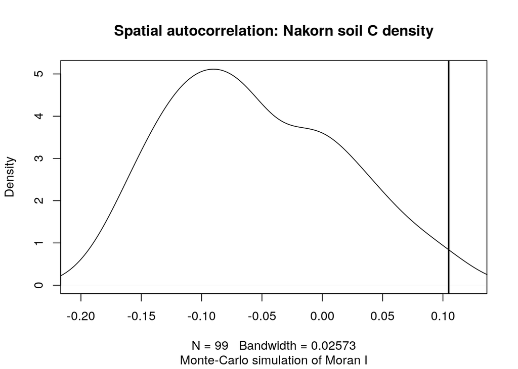

## Quick mixed effects model of species effect

```
## # A tibble: 7 x 3
##   site   dom_genus     n
##   <chr>  <chr>     <int>
## 1 Krabi  rh            5
## 2 Krabi  rh_mix       17
## 3 Krabi  xy_mix        4
## 4 Nakorn br_mix        6
## 5 Nakorn br            3
## 6 Nakorn av_mix        4
## 7 Nakorn rh_mix        5
```

#### Looking at filtered data:

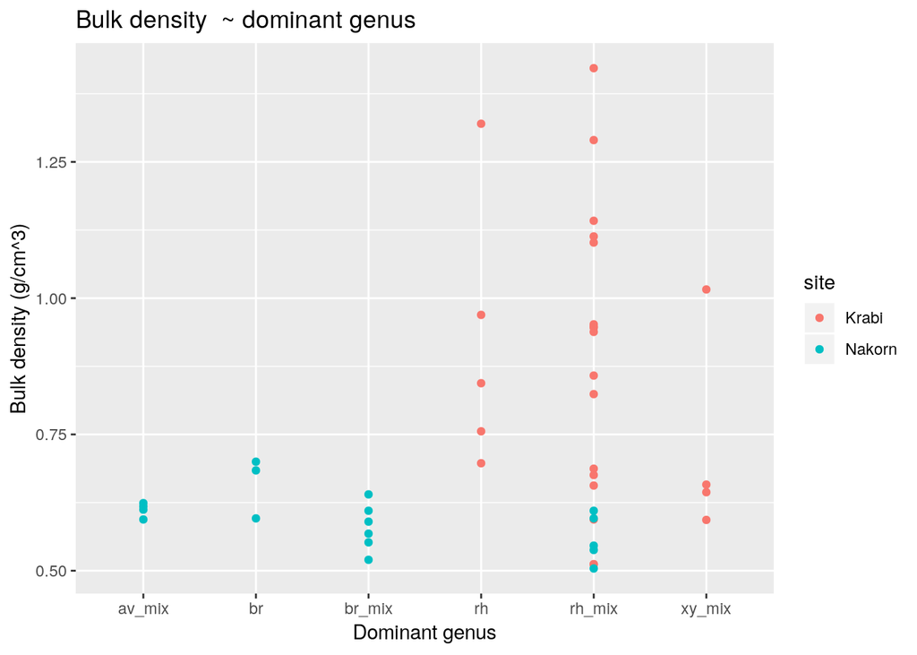

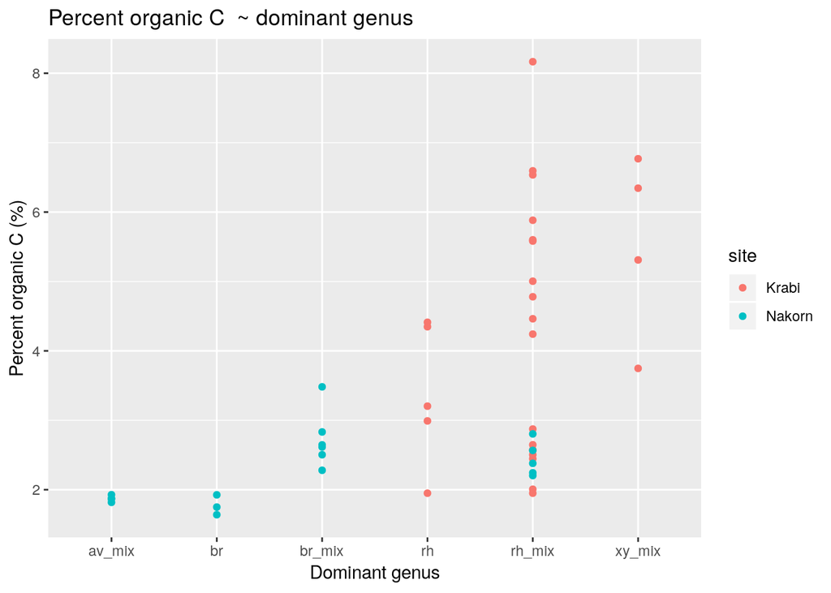

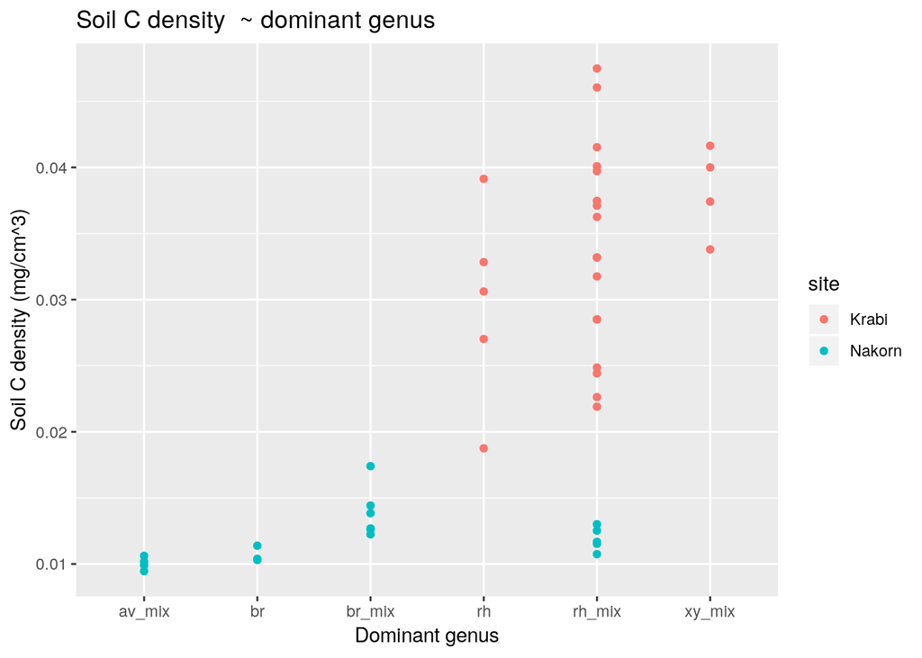

Subset to just Krabi, given that there is only n = 2 per transect in Nakorn and thus have singular convergence.

Run 2 models:

1. Null model with percent organic carbon predicted by total biomass, random intercept by plot (account for plotwise correlation)
2. LME model with percent organic carbon predicted by dom genus + total biomass, random intercept by plot (account for plotwise correlation)

Run an ANOVA between the two models to test for significance of alternative model.

#### Null model

```r
null <- lme4::lmer(subplot_poc ~ subplot_ttl_ha + (1|plot),
                   data = filter(filt_mdl_dat, site == "Krabi"), REML = FALSE)
summary(null)
```

```
## Linear mixed model fit by maximum likelihood  ['lmerMod']
## Formula: subplot_poc ~ subplot_ttl_ha + (1 | plot)
##    Data: filter(filt_mdl_dat, site == "Krabi")
##
##      AIC      BIC   logLik deviance df.resid
##     96.6    101.7    -44.3     88.6       22
##
## Scaled residuals:
##      Min       1Q   Median       3Q      Max
## -2.61580 -0.43266 -0.08924  0.67163  2.28833
##
## Random effects:
##  Groups   Name        Variance Std.Dev.
##  plot     (Intercept) 1.927    1.388
##  Residual             1.014    1.007
## Number of obs: 26, groups:  plot, 7
##
## Fixed effects:
##                  Estimate Std. Error t value
## (Intercept)     4.4083465  1.0549219   4.179
## subplot_ttl_ha -0.0008918  0.0054494  -0.164
##
## Correlation of Fixed Effects:
##             (Intr)
## sbplt_ttl_h -0.846
```

#### LME model

```r
lmm <- lme4::lmer(subplot_poc ~ subplot_ttl_ha + dom_genus + (1|plot),
                  data = filter(filt_mdl_dat, site == "Krabi"), REML = FALSE)
summary(lmm)
```

```
## Linear mixed model fit by maximum likelihood  ['lmerMod']
## Formula: subplot_poc ~ subplot_ttl_ha + dom_genus + (1 | plot)
##    Data: filter(filt_mdl_dat, site == "Krabi")
##
##      AIC      BIC   logLik deviance df.resid
##     92.7    100.2    -40.3     80.7       20
##
## Scaled residuals:
##      Min       1Q   Median       3Q      Max
## -2.01017 -0.57464 -0.06651  0.61564  2.57247
##
## Random effects:
##  Groups   Name        Variance Std.Dev.
##  plot     (Intercept) 1.8407   1.3567
##  Residual             0.6875   0.8292
## Number of obs: 26, groups:  plot, 7
##
## Fixed effects:
##                   Estimate Std. Error t value
## (Intercept)      3.4215013  0.9803498   3.490
## subplot_ttl_ha  -0.0009782  0.0045231  -0.216
## dom_genusrh_mix  1.1364849  0.4862854   2.337
## dom_genusxy_mix  1.8247154  0.5995319   3.044
##
## Correlation of Fixed Effects:
##             (Intr) sbpl__ dm_gnsr_
## sbplt_ttl_h -0.744
## dm_gnsrh_mx -0.343 -0.041
## dm_gnsxy_mx -0.294  0.015  0.607
```

#### Model comparison via ANOVA

```r
anova(null, lmm)
```

```
## Data: filter(filt_mdl_dat, site == "Krabi")
## Models:
## null: subplot_poc ~ subplot_ttl_ha + (1 | plot)
## lmm: subplot_poc ~ subplot_ttl_ha + dom_genus + (1 | plot)
##      Df    AIC    BIC  logLik deviance  Chisq Chi Df Pr(>Chisq)
## null  4 96.630 101.66 -44.315   88.630
## lmm   6 92.655 100.20 -40.328   80.655 7.9746      2    0.01855 *
## ---
## Signif. codes:  0 '***' 0.001 '**' 0.01 '*' 0.05 '.' 0.1 ' ' 1
```

## Same comparison for bulk density

#### Null model

```r
null <- lme4::lmer(subplot_bd ~ subplot_ttl_ha + (1|plot),
                   data = filter(filt_mdl_dat, site == "Krabi"), REML = FALSE)
summary(null)
```

```
## Linear mixed model fit by maximum likelihood  ['lmerMod']
## Formula: subplot_bd ~ subplot_ttl_ha + (1 | plot)
##    Data: filter(filt_mdl_dat, site == "Krabi")
##
##      AIC      BIC   logLik deviance df.resid
##     -1.9      3.2      4.9     -9.9       22
##
## Scaled residuals:
##      Min       1Q   Median       3Q      Max
## -1.21040 -0.68158 -0.09677  0.49296  2.19611
##
## Random effects:
##  Groups   Name        Variance Std.Dev.
##  plot     (Intercept) 0.04132  0.2033
##  Residual             0.02334  0.1528
## Number of obs: 26, groups:  plot, 7
##
## Fixed effects:
##                 Estimate Std. Error t value
## (Intercept)    0.8231419  0.1585059   5.193
## subplot_ttl_ha 0.0004218  0.0008255   0.511
##
## Correlation of Fixed Effects:
##             (Intr)
## sbplt_ttl_h -0.853
```

#### LME model

```r
lmm <- lme4::lmer(subplot_bd ~ subplot_ttl_ha + dom_genus + (1|plot),
                  data = filter(filt_mdl_dat, site == "Krabi"), REML = FALSE)
summary(lmm)
```

```
## Linear mixed model fit by maximum likelihood  ['lmerMod']
## Formula: subplot_bd ~ subplot_ttl_ha + dom_genus + (1 | plot)
##    Data: filter(filt_mdl_dat, site == "Krabi")
##
##      AIC      BIC   logLik deviance df.resid
##     -0.2      7.3      6.1    -12.2       20
##
## Scaled residuals:
##     Min      1Q  Median      3Q     Max
## -1.2780 -0.7328  0.0632  0.5024  2.1801
##
## Random effects:
##  Groups   Name        Variance Std.Dev.
##  plot     (Intercept) 0.03986  0.1996
##  Residual             0.02096  0.1448
## Number of obs: 26, groups:  plot, 7
##
## Fixed effects:
##                   Estimate Std. Error t value
## (Intercept)      0.9014260  0.1635775   5.511
## subplot_ttl_ha   0.0004098  0.0007848   0.522
## dom_genusrh_mix -0.0809151  0.0843873  -0.959
## dom_genusxy_mix -0.1643435  0.1043148  -1.575
##
## Correlation of Fixed Effects:
##             (Intr) sbpl__ dm_gnsr_
## sbplt_ttl_h -0.774
## dm_gnsrh_mx -0.358 -0.039
## dm_gnsxy_mx -0.304  0.012  0.606
```

#### Model comparison via ANOVA

```r
anova(null, lmm)
```

```
## Data: filter(filt_mdl_dat, site == "Krabi")
## Models:
## null: subplot_bd ~ subplot_ttl_ha + (1 | plot)
## lmm: subplot_bd ~ subplot_ttl_ha + dom_genus + (1 | plot)
##      Df     AIC    BIC logLik deviance  Chisq Chi Df Pr(>Chisq)
## null  4 -1.8650 3.1673 4.9325   -9.865
## lmm   6 -0.2264 7.3222 6.1132  -12.226 2.3614      2     0.3071
```

## Same comparison for soil carbon density

#### Null model

```r
null <- lme4::lmer(subplot_c_dens ~ subplot_ttl_ha + (1|plot),
                   data = filter(filt_mdl_dat, site == "Krabi"), REML = FALSE)
summary(null)
```

```
## Linear mixed model fit by maximum likelihood  ['lmerMod']
## Formula: subplot_c_dens ~ subplot_ttl_ha + (1 | plot)
##    Data: filter(filt_mdl_dat, site == "Krabi")
##
##      AIC      BIC   logLik deviance df.resid
##   -181.9   -176.9     94.9   -189.9       22
##
## Scaled residuals:
##     Min      1Q  Median      3Q     Max
## -1.7128 -0.5397 -0.1223  0.6994  1.6471
##
## Random effects:
##  Groups   Name        Variance  Std.Dev.
##  plot     (Intercept) 2.770e-05 0.005263
##  Residual             2.565e-05 0.005064
## Number of obs: 26, groups:  plot, 7
##
## Fixed effects:
##                 Estimate Std. Error t value
## (Intercept)    3.172e-02  4.960e-03   6.395
## subplot_ttl_ha 1.255e-05  2.703e-05   0.464
##
## Correlation of Fixed Effects:
##             (Intr)
## sbplt_ttl_h -0.893
```

#### LME model

```r
lmm <- lme4::lmer(subplot_c_dens ~ subplot_ttl_ha + dom_genus + (1|plot),
                  data = filter(filt_mdl_dat, site == "Krabi"), REML = FALSE)
summary(lmm)
```

```
## Linear mixed model fit by maximum likelihood  ['lmerMod']
## Formula: subplot_c_dens ~ subplot_ttl_ha + dom_genus + (1 | plot)
##    Data: filter(filt_mdl_dat, site == "Krabi")
##
##      AIC      BIC   logLik deviance df.resid
##   -182.0   -174.4     97.0   -194.0       20
##
## Scaled residuals:
##      Min       1Q   Median       3Q      Max
## -1.33750 -0.77422 -0.03139  0.89229  1.39656
##
## Random effects:
##  Groups   Name        Variance  Std.Dev.
##  plot     (Intercept) 2.662e-05 0.005160
##  Residual             2.121e-05 0.004605
## Number of obs: 26, groups:  plot, 7
##
## Fixed effects:
##                  Estimate Std. Error t value
## (Intercept)     2.876e-02  4.977e-03   5.778
## subplot_ttl_ha  1.360e-05  2.472e-05   0.550
## dom_genusrh_mix 2.758e-03  2.659e-03   1.037
## dom_genusxy_mix 6.918e-03  3.301e-03   2.096
##
## Correlation of Fixed Effects:
##             (Intr) sbpl__ dm_gnsr_
## sbplt_ttl_h -0.802
## dm_gnsrh_mx -0.375 -0.035
## dm_gnsxy_mx -0.312  0.009  0.604
```

#### Model comparison via ANOVA

```r
anova(null, lmm)
```

```
## Data: filter(filt_mdl_dat, site == "Krabi")
## Models:
## null: subplot_c_dens ~ subplot_ttl_ha + (1 | plot)
## lmm: subplot_c_dens ~ subplot_ttl_ha + dom_genus + (1 | plot)
##      Df     AIC     BIC logLik deviance  Chisq Chi Df Pr(>Chisq)
## null  4 -181.88 -176.85 94.942  -189.88
## lmm   6 -181.98 -174.43 96.988  -193.98 4.0908      2     0.1293
```

## Quick summary:

Find significant effect of species on percent organic carbon, but not bulk density or soil carbon density (product of POC and bulk density).

Tends to align with what we’d expect given species vs. environmental setting influences? bulk density determined by sedimentation, whereas organic matter input to soil can be influence by vegetation morphology.